# Computational Statistics HW7

吴嘉骜 21307130203

2023-11-23

## ex 7.3

Obtain a bootstrap t confidence interval estimate for the correlation statistic in Example 7.2 ($\texttt{law}$ data in $\texttt{bootstrap}$).

Solution.

```r
library(bootstrap)
# Compute the Bootstrap standard error
seboot <- function(data, B){
  n <- nrow(data)
  thetaboot <- numeric(B)
  for(b in 1:B){
    i <- sample(1:n, size = n, replace = TRUE)
    x <- data[i,1]
    y <- data[i,2]
    thetaboot[b] <- cor(x,y)
  }
  return(sd(thetaboot))
}

n <- nrow(law)
thhat <- cor(law$LSAT,law$GPA)

B <- 200
R <- 100
thhat.b <- numeric(B)
se.thhat.b <- numeric(B)
for(b in 1:B){
  j <- sample(1:n, size = n, replace = TRUE)
  x <- law$LSAT[j]
  y <- law$GPA[j]
  thhat.b[b] <- cor(x,y)
  se.thhat.b[b] <- seboot(cbind(x,y), R)
}
se.thhat <- sd(thhat.b)
t_stat <- (thhat.b - thhat)/se.thhat.b
alpha <- 0.05
qt <- quantile(t_stat, c(alpha/2, 1-alpha/2), type=1)
names(qt) <- rev(names(qt))  # reverse the order of the names
ci <- rev(thhat - qt*se.thhat)
ci
```

```
##      2.5%     97.5%
## 0.0876142 1.0410721
```

## ex 7.10

In Example 7.18, leave-one-out ($n$-fold) cross validation was used to select the best fitting model. Repeat the analysis replacing the Log-Log model with a cubic polynomial model. Which of the four models is selected by the cross validation procedure? Which model is selected according to maximum adjusted $R^2$?

Solution.

```r
library(DAAG, warn.conflict = FALSE); attach(ironslag)
a <- seq(10, 40, .1) #sequence for plotting fits

# n-fold cross validation
n <- nrow(ironslag)
e1 <- e2 <- e3 <- e4 <- numeric(n)

for(k in 1:n){
  y <- magnetic[-k]
  x <- chemical[-k]

  J1 <- lm(y ~ x)
  J2 <- lm(y ~ x + I(x^2))
  J3 <- lm(log(y) ~ x)
  J4 <- lm(y ~ x + I(x^2) + I(x^3))

  x0 <- data.frame(x=chemical[k])
  e1[k] <- magnetic[k] - predict(J1, x0)
  e2[k] <- magnetic[k] - predict(J2, x0)
  e3[k] <- magnetic[k] - exp(predict(J3, x0))
  e4[k] <- magnetic[k] - predict(J4, x0)
}
print(list(Linear = mean(e1^2), Quadratic = mean(e2^2), Exponential = mean(e3^2), Cubic = mean(e4^2)))
```

```
## $Linear
## [1] 19.55644
##
## $Quadratic
## [1] 17.85248
##
## $Exponential
## [1] 18.44188
##
## $Cubic
## [1] 18.17756
```

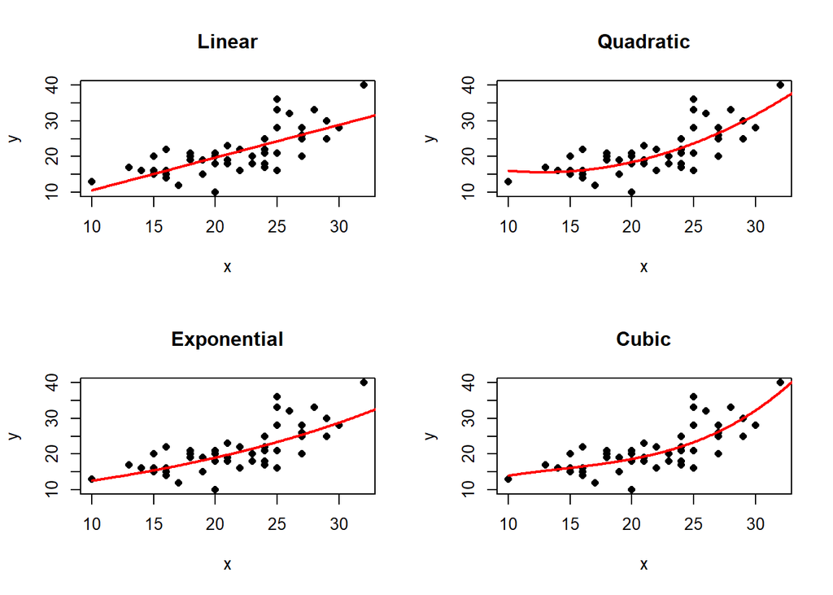

```r
# model selection by R_a^2
y <- magnetic
x <- chemical
par(mfrow=c(2,2))

L1 <- lm(y ~ x)
plot(x, y, main = "Linear", pch=16)
lines(a, predict(L1, data.frame(x=a)), col="red", lwd=2)

L2 <- lm(y ~ x + I(x^2))
plot(x, y, main = "Quadratic", pch=16)
lines(a, predict(L2, data.frame(x=a)), col="red", lwd=2)

L3 <- lm(log(y) ~ x)
plot(x, y, main = "Exponential", pch=16)
lines(a, exp(predict(L3, data.frame(x=a))), col="red", lwd=2)

L4 <- lm(y ~ x + I(x^2) + I(x^3))
plot(x, y, main = "Cubic", pch=16)
lines(a, predict(L4, data.frame(x=a)), col="red", lwd=2)
```

```r
par(mfrow = c(1, 1))

Ra <- matrix(0, nrow = 1, ncol = 4)
Ra[1] <- summary(L1)$adj.r.squared
Ra[2] <- summary(L2)$adj.r.squared
Ra[3] <- summary(L3)$adj.r.squared
Ra[4] <- summary(L4)$adj.r.squared
rownames(Ra) <- "R_a^2"
colnames(Ra) <- c("Linear", "Quadratic", "Exponential", "Cubic")
Ra
```

```
##          Linear Quadratic Exponential     Cubic
## R_a^2 0.5281545 0.5768151   0.5280556 0.5740396
```

From the cross validation procedure, the quadratic model has the smallest prediction error, and is thus selected.

According to maximum adjusted $R^2$, the quadratic model is also selected.

## ex 7.11

In Example 7.18, leave-one-out ($n$-fold) cross validation was used to select the best fitting model. Use leave-two-out cross validation to compare the models.

Solution.

```r
library(DAAG, warn.conflict = FALSE)
attach(ironslag)

# n-fold cross validation
n <- nrow(ironslag)
N <- choose(n, 2)
e1 <- e2 <- e3 <- e4 <- numeric(N)
k <- 1
for(i in 1:(n-1)){
  for(j in (i+1):n){
    y <- magnetic[-c(i,j)]
    x <- chemical[-c(i,j)]

    J1 <- lm(y ~ x)
    J2 <- lm(y ~ x + I(x^2))
    J3 <- lm(log(y) ~ x)
    J4 <- lm(log(y) ~ log(x))

    x0 <- data.frame(x=chemical[c(i,j)])
    e1[k] <- sum((magnetic[c(i,j)] - predict(J1, x0))^2)
    e2[k] <- sum((magnetic[c(i,j)] - predict(J2, x0))^2)
    e3[k] <- sum((magnetic[c(i,j)] - exp(predict(J3, x0)))^2)
    e4[k] <- sum((magnetic[c(i,j)] - exp(predict(J4, x0)))^2)

    k <- k + 1
  }
}

detach(ironslag)
detach(package:DAAG)
print(list(Linear = mean(e1), Quadratic = mean(e2), Exponential = mean(e3), LogLog = mean(e4)))
```

```
## $Linear
## [1] 39.14455
##
## $Quadratic
## [1] 35.74037
##
## $Exponential
## [1] 36.90983
##
## $LogLog
## [1] 40.93436
```

The quadratic model is again selected by leave-two-out cross validation due to its smallest prediction error.

## pj 7.A

Conduct a Monte Carlo study to estimate the coverage probabilities of the standard normal bootstrap confidence interval, the basic bootstrap confidence interval, and the percentile confidence interval. Sample from a normal population and check the empirical coverage rates for the sample mean. Find the proportion of times that the confidence intervals miss on the left, and the proportion of times that the confidence intervals miss on the right.

Solution.

```r
library(boot)
# Preparations
n <- 100  # sample size
M <- 250  # number of Monte Carlo samples
B <- 200  # number of bootstrap samples
mu <- 100  # true value
sigma <- 10  # true value
alpha <- c(0.025, 0.975)  # confidence level
set.seed(2023)  # for reproducibility

# records initialization
cover_std <- cover_basic <- cover_perc <- numeric(M)
miss_left_std <- miss_left_basic <- miss_left_perc <- numeric(M)
miss_right_std <- miss_right_basic <- miss_right_perc <- numeric(M)

# Monte Carlo simulation
for(m in 1:M){
  x <- rnorm(n, mu, sigma)
  muh <- mean(x)
  se <- sd(x)/sqrt(n)
  muboot <- replicate(B, mean(sample(x, n, replace = TRUE)))

  # Standard normal bootstrap confidence interval
  CI1 <- muh + qnorm(alpha) * sd(muboot)
  # Basic bootstrap confidence interval
  CI2 <- 2 * muh - quantile(muboot, rev(alpha))
  # Percentile confidence interval
  CI3 <- quantile(muboot, alpha)

  # Coverage rates
  cover_std[m] <- (mu >= CI1[1] & mu <= CI1[2])
  cover_basic[m] <- (mu >= CI2[1] & mu <= CI2[2])
  cover_perc[m] <- (mu >= CI3[1] & mu <= CI3[2])

  # Miss rates
  miss_left_std[m] <- (mu < CI1[1])
  miss_left_basic[m] <- (mu < CI2[1])
  miss_left_perc[m] <- (mu < CI3[1])
  miss_right_std[m] <- (mu > CI1[2])
  miss_right_basic[m] <- (mu > CI2[2])
  miss_right_perc[m] <- (mu > CI3[2])
}

results <- data.frame(
  Interval_Type = c("Standard Normal", "Basic", "Percentile"),
  Coverage = c(mean(cover_std), mean(cover_basic), mean(cover_perc)),
  Miss_Left = c(mean(miss_left_std), mean(miss_left_basic), mean(miss_left_perc)),
  Miss_Right = c(mean(miss_right_std), mean(miss_right_basic), mean(miss_right_perc))
)

results
```

```
##     Interval_Type Coverage Miss_Left Miss_Right
## 1 Standard Normal    0.944     0.036      0.020
## 2           Basic    0.944     0.032      0.024
## 3      Percentile    0.948     0.036      0.016
```

## pj 7.B

Repeat Project 7.A for the sample skewness statistic. Compare the coverage rates for normal populations (skewness 0) and $\chi^2(5)$ distributions (positive skewness).

Solution.

```r
library(boot)
# Preparations
n <- 10000  # sample size
M <- 200  # number of Monte Carlo samples
B <- 500  # number of bootstrap samples
mu <- 10  # true value
sigma <- 1  # true value
alpha <- c(0.025, 0.975)  # confidence level

# compute the sample skewness
skew <- function(x){
  xbar <- mean(x)
  m3 <- mean((x - xbar)^3)
  m2 <- mean((x - xbar)^2)
  m3/m2^1.5
}
set.seed(1234)  # for reproducibility

# Result initialization
results <- matrix(0, nrow = 9, ncol = 2)
rownames(results) <- c("Coverage_Std", "Coverage_Basic", "Coverage_Perc",
                       "Miss_Left_Std", "Miss_Right_Std", "Miss_Left_Basic", "Miss_Right_Basic", "Miss_Left_Perc", "Miss_Right_Perc")
colnames(results) <- c("Normal", "Chi_Squared")

MC_simu <- function(dist){
  # records initialization
  cover_std <- cover_basic <- cover_perc <- numeric(M)
  miss_left_std <- miss_left_basic <- miss_left_perc <- numeric(M)
  miss_right_std <- miss_right_basic <- miss_right_perc <- numeric(M)

  # Monte Carlo simulation
  for(m in 1:M){
    if (dist == "Normal") {
      x <- rnorm(n, mu, sigma)
      sk <- 0
    } else if (dist == "Chi_Squared") {
      x <- rchisq(n, df = 5)
      sk <- sqrt(8/5)
    }
    skh <- skew(x)
    skboot <- replicate(B, skew(sample(x, n, replace = TRUE)))


    # Standard normal bootstrap confidence interval
    CI1 <- skh + qnorm(alpha) * sd(skboot)
    # Basic bootstrap confidence interval
    CI2 <- 2 * skh - quantile(skboot, rev(alpha))
    # Percentile confidence interval
    CI3 <- quantile(skboot, alpha)

    # Coverage rates
    cover_std[m] <- (sk >= CI1[1] & sk <= CI1[2])
    cover_basic[m] <- (sk >= CI2[1] & sk <= CI2[2])
    cover_perc[m] <- (sk >= CI3[1] & sk <= CI3[2])

    # Miss rates
    miss_left_std[m] <- (sk < CI1[1])
    miss_left_basic[m] <- (sk < CI2[1])
    miss_left_perc[m] <- (sk < CI3[1])
    miss_right_std[m] <- (sk > CI1[2])
    miss_right_basic[m] <- (sk > CI2[2])
    miss_right_perc[m] <- (sk > CI3[2])
}


  c(mean(cover_std), mean(cover_basic), mean(cover_perc),
      mean(miss_left_std), mean(miss_right_std),
      mean(miss_left_basic), mean(miss_right_basic),
      mean(miss_left_perc), mean(miss_right_perc))
}

results[, "Normal"] <- MC_simu("Normal")
results[, "Chi_Squared"] <- MC_simu("Chi_Squared")

results
```

```
##                  Normal Chi_Squared
## Coverage_Std      0.945       0.965
## Coverage_Basic    0.950       0.960
## Coverage_Perc     0.955       0.960
## Miss_Left_Std     0.015       0.000
## Miss_Right_Std    0.040       0.035
## Miss_Left_Basic   0.020       0.000
## Miss_Right_Basic  0.030       0.040
## Miss_Left_Perc    0.020       0.005
## Miss_Right_Perc   0.025       0.035
```

When sample size $n$ is as small as Project 7.A, the coverage rates for skewness of $\chi^2(5)$ distributions are not satisfactory. This is probably because the sample skewness formula has a large variance, and the sample size should be large enough to make the sample skewness close to the population skewness. But it needs much more computational time to achieve a better estimate.